# Median and Mean CPUE

Alexander Steer-Milnes

28/10/2021

## Comparing Median and Mean CPUE

First we need to calculate the catch per unit efficiency. CPUE is mesured in kg/h so we need to change our date somewhat before calculating this.

we’ll start with the previously cleaned ladings data and work from there.

```
##       Year              Date         Trip_ID        Effort_Hours
##  Min.   :2003   2014-01-25:  84   Min.   :   1.0   Min.   : 5.000
##  1st Qu.:2005   2004-05-13:  82   1st Qu.: 151.0   1st Qu.: 8.000
##  Median :2012   2013-12-21:  72   Median : 280.0   Median : 9.000
##  Mean   :2010   2004-05-17:  70   Mean   : 374.8   Mean   : 9.488
##  3rd Qu.:2014   2003-09-20:  61   3rd Qu.: 502.0   3rd Qu.:10.000
##  Max.   :2014   2004-05-16:  61   Max.   :1670.0   Max.   :16.000
##                 (Other)   :6778
##        Gear               Species       Length_cm        Weight_g
##  Gillnet :  42   Caesio cuning:7208   Min.   : 2.00   Min.   :    0.17
##  Handline:1652                        1st Qu.:23.00   1st Qu.:  279.96
##  Muroami :1547                        Median :25.00   Median :  360.49
##  Speargun:2596                        Mean   :25.46   Mean   :  449.43
##  Trap    :1333                        3rd Qu.:27.00   3rd Qu.:  455.24
##  Trolling:  38                        Max.   :96.00   Max.   :21316.02
##
```

Firstly our data has weight in grams, so we want to change this to Kilograms. Secondly we can group by year and trip ID so we can calculate the CPUE for each year. Thirdly we can actually calculate CPUE by taking the total weight of the catch and dividing by the number of hours for each trip.

```
## # A tibble: 1,880 x 3
## # Groups:   Year [9]
##     Year Trip_ID Trip_CPUE
##    <int>   <int>     <dbl>
##  1  2003       1    1.25
##  2  2003       2    0.315
##  3  2003      10    0.186
##  4  2003      15    0.251
##  5  2003      16    0.0565
##  6  2003      18    0.0837
##  7  2003      22    0.0455
##  8  2003      23    0.318
##  9  2003      24    0.177
## 10  2003      31    0.100
## # ... with 1,870 more rows
```

Now we want to compare both the median and mean of the CPUE for each year.

```
## # A tibble: 9 x 3
##    Year CPUE_KgpH Type
##   <int>     <dbl> <chr>
## 1  2003    0.318  Median
## 2  2004    0.262  Median
## 3  2005    0.401  Median
## 4  2006    0.440  Median
## 5  2010    0.0174 Median
## 6  2011    0.0312 Median
## 7  2012    0.0312 Median
## 8  2013    0.196  Median
## 9  2014    0.882  Median
```

```
## # A tibble: 9 x 3
##    Year CPUE_KgpH Type
##   <int>     <dbl> <chr>
## 1  2003    0.493  Mean
## 2  2004    0.330  Mean
## 3  2005    0.403  Mean
## 4  2006    0.458  Mean
## 5  2010    0.0202 Mean
## 6  2011    0.0346 Mean
## 7  2012    0.0357 Mean
## 8  2013    0.304  Mean
## 9  2014    1.45   Mean
```

This is easier to visulaise in a plot.

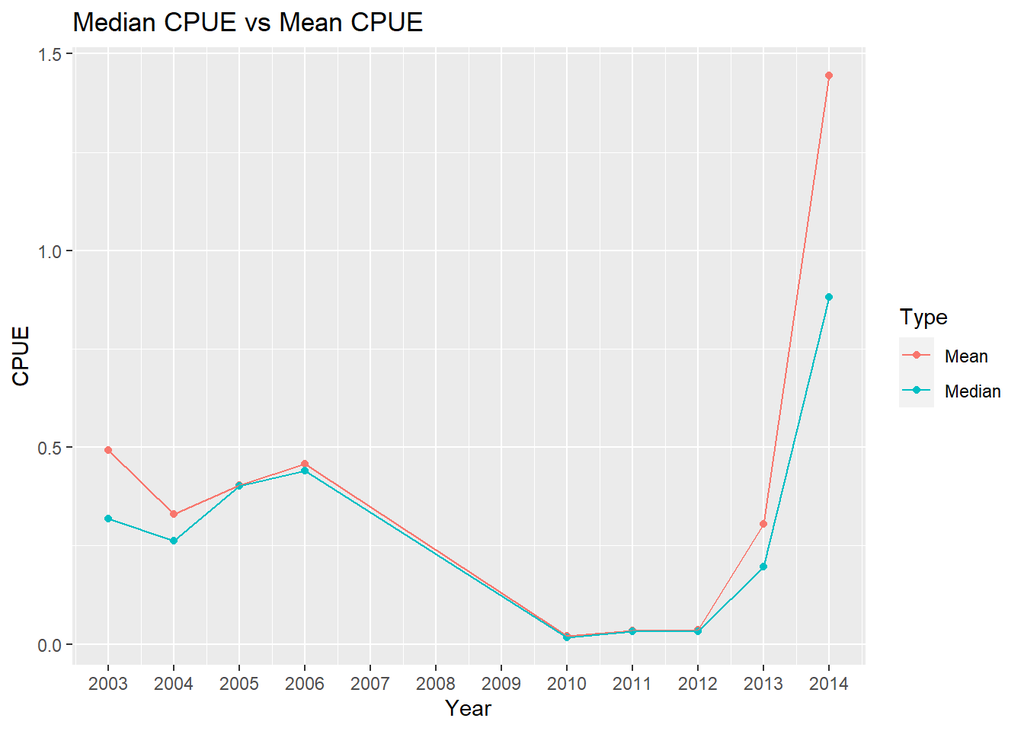

We can see that between 2005 and 2012 the Mean (in red) and median (in blue) are very close. However in 2003, 2004, 2013 and 2014 the mean is significantly higher than the median this might suggest that some trips were significantly higher in CPUE that the rest for those years